## N7: Computational approaches

```
Stephen J Eglen                  DAMTP (Applied Maths/Theoretical Physics)
https://sje30.github.io          University of Cambridge
sje30@cam.ac.uk
```

HTML Slides: <https://sje30.github.io/n7> (CC BY 4.0 license)

# Part one: introduction

## Why model?

* Everyone models.

* Model system (zebrafish / mouse / organoids).

* I just happen to use the language of maths/computers rather than
    verbal arguments.

[figure not shown]

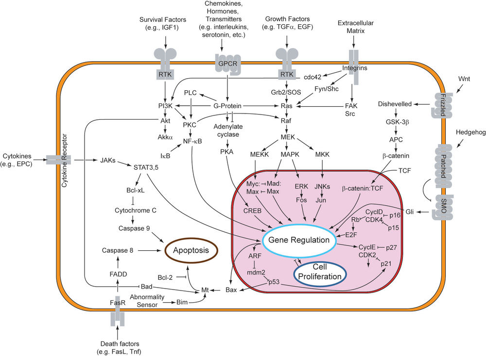

https://en.wikipedia.org/wiki/Cell_signaling

## What can we do with modelling

* Quantitative modelling: test that theories hold true, or test their
  limits.

* Qualitative modelling: make abstract models to capture essence of a
  system.  (cf. epidemiological modelling since 2020).

* Experiments test for *necessity*; models test for *sufficiency*.

* Make predictions  about novel situations.

* Made postdictions to explain past data sets (Abbott 2008).

# Part two: Physiological models

We start with classic Hodgkin and Huxley (1952) model.

## Mathematical description of ion channels

Voltage-gated channels: gating variables [0,1] to represent flow of ions.

For given voltage, e.g. K channel activation, gated by `\(n\)`:

(1-n) Gates switch from closed state to open state with rate `\(\alpha\)`.

(n) Gates switch from open state to closed state with rate `\(\beta\)`.

i.e.
	$$ \frac{dn}{dt} = \alpha(1-n) - \beta n $$

The terms `\(\alpha\)` and `\(\beta\)` themselves depend on membrane voltage

Similar expressions can be created for sodium activiation (m) and
inactivation (h).

## Ionic flow determines membrane voltage.

We can derive an expression:

`$$c_m \frac{dV}{dt} = -g_L (E_L - V) - g_{Na} m^3 h (E_{Na} - V) - g_K n^4(E_K - V) + I_e$$`

where the `\(g\)` terms are the maximal conductances for each channel, and
the `\(E\)` terms are the resting potentials for each channel.

This leads to four coupled differential equations.

Solving these requires methods of *numerical integration*.

## Demonstration

Live demo of all-or-nothing behaviour:

<https://demonstrations.wolfram.com/HodgkinHuxleyActionPotentialModel/>

As you vary external stimulus you can see emergence of an action
potential.

## Dynamics of channels and membrane voltage

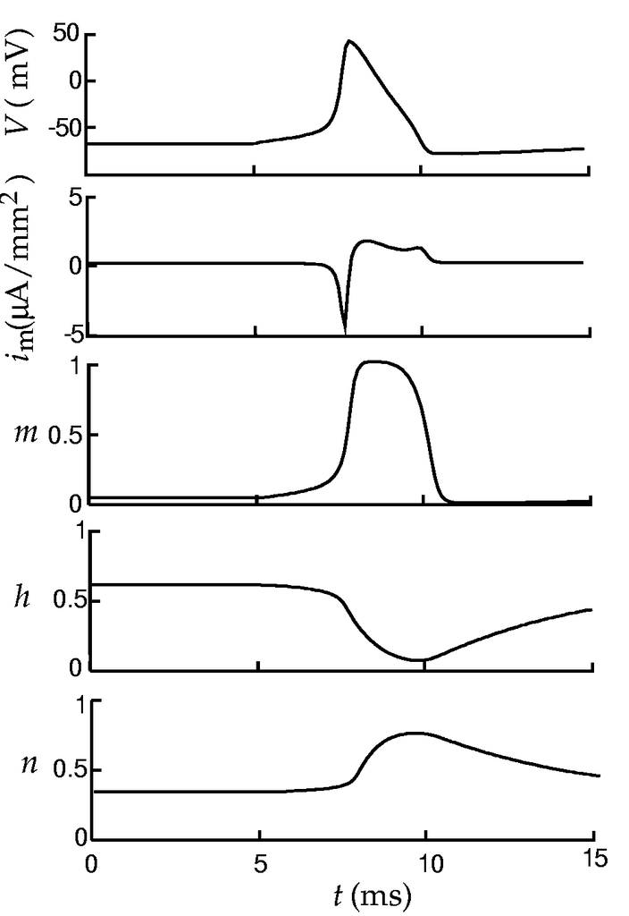

Dayan and Abbott (2002) fig 5.11.

## Goodness of fit

Hodgkin and Huxley(1952).  Reproduced from David Sterratt.  Upper
trace: model; numbers give initial depolarisations (in mV);
recordings at 6~C.

Data taken from squid giant axon; much wider axonal diameter (800
um) than normal (2 um) for rapid signal propagation [escape behaviour].

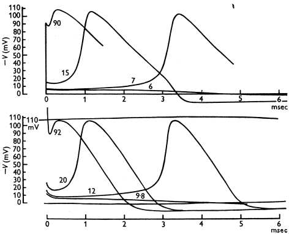

## Simplifications to H-H framework

Two observations (Rinzel, 1985):

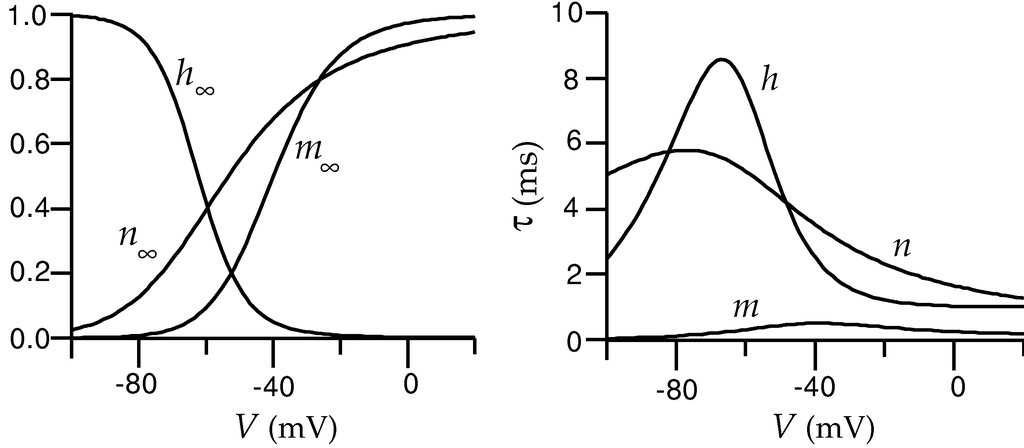

Dayan and Abbott (2002) fig 5.10.

1. `\(m\)` reaches steady-state almost instantaneously.

2. `\(h\)` and `\(1-n\)` have similar voltage dependence, so model just one of
   them.

## Rinzel simplification vs HH model

Wilson (1999) Fig 9.3.  Comparison of HH model with Rinzel
approximation (eqn 9.7).  Both systems produce a reduced spike
amplitude at higher frequencies.

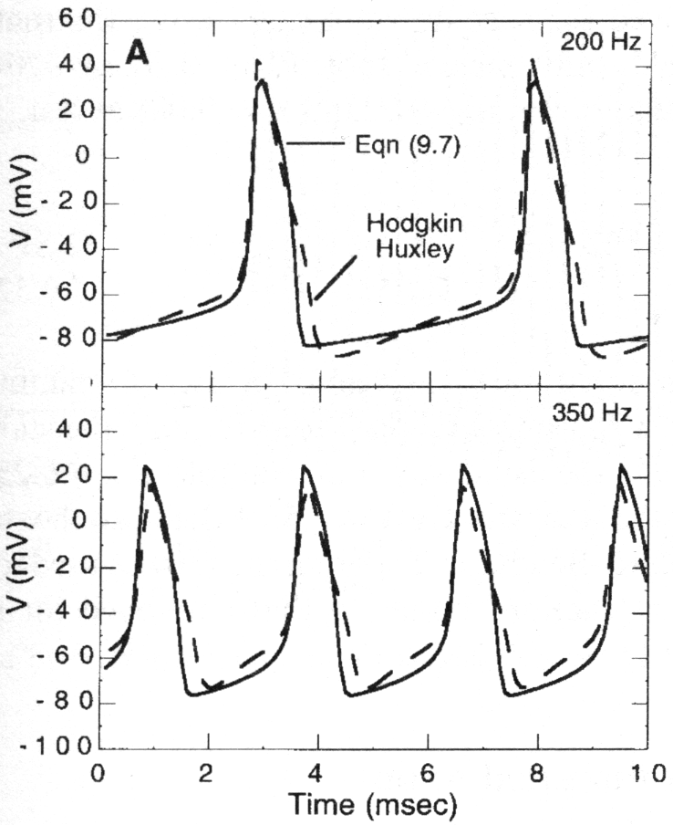

## What is the 'right model' to use?

Various simplifications to Hodgkin-Huxley (Izhikevich, 2004; Figure 2):

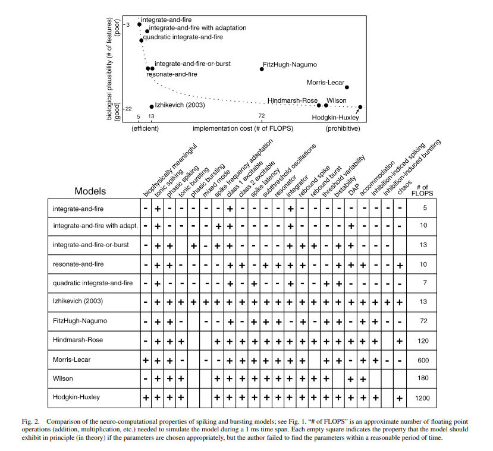

## What is the Izhikevich (2003) model?

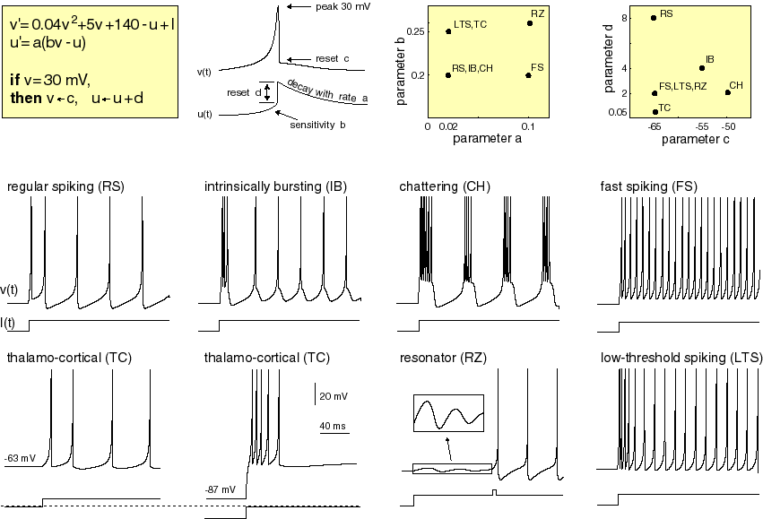

## Application of Izhikevich model neurons

We can now build model circuits using these neurons.  e.g. Tomkova et
al 2015: <https://paperpile.com/app/p/5529195b-9246-0d04-8449-09b3cc7289db>

## Dynamic clamp

Dynamic clamp takes membrane voltage, and simulates current that
  will pass through a particular channel; that channel is injected
  real-time, as if that channel existed on the neuron.

This allows us to use biology to worry about all the other
  conductances, rather than a modeller using poor estimates of the
  conductances.

## Dynamic clamp application

Can two mutually inhibitory neurons fire in synchrony?

Use dynamic clamp to *virtually* connect two neurons.

Marder and Abbott 1995, Fig 2

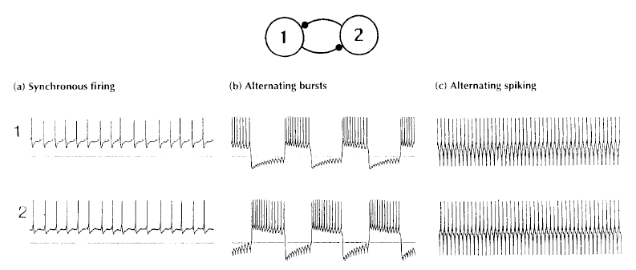

# Part three: Anatomical models

## Retinal mosaics: `\(\alpha\)` retinal ganglion cells

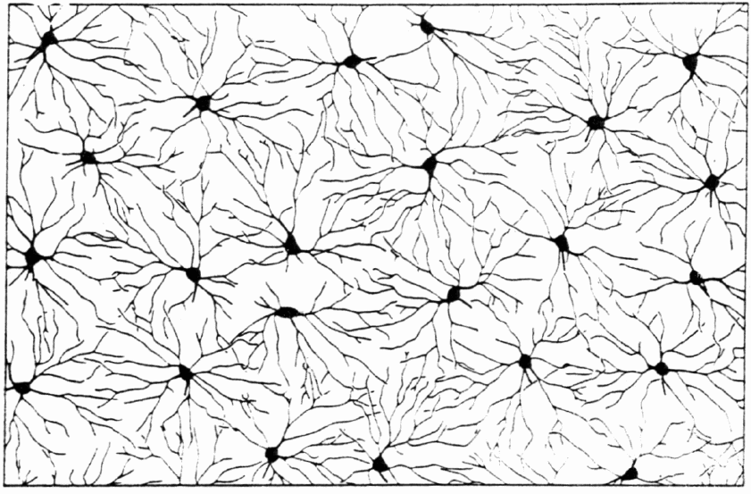

`\(1.7 \times 1.2\)` mm staining of cat retina  (Wässle et al., 1981).

## Minimal distance (``dmin'') serial model

[figure not shown]